# EXST 7014: Lab1 Assignment

Somnath Mukherjee

January 22, 2019

### Install and load required packages

```
##      knitr kableExtra    ggplot2     plotly
##       TRUE       TRUE       TRUE       TRUE
```

### Read the input file before answering questions

```r
fw07p06 = read.table("data_lab1.txt", header = FALSE, sep = "", dec = ".")
colnames(fw07p06)=c("CITY","STATE","LAT","RANGE")
```

### 1. Produce a scatter plot to show the relationship between RANGE and LAT. What is your observation?

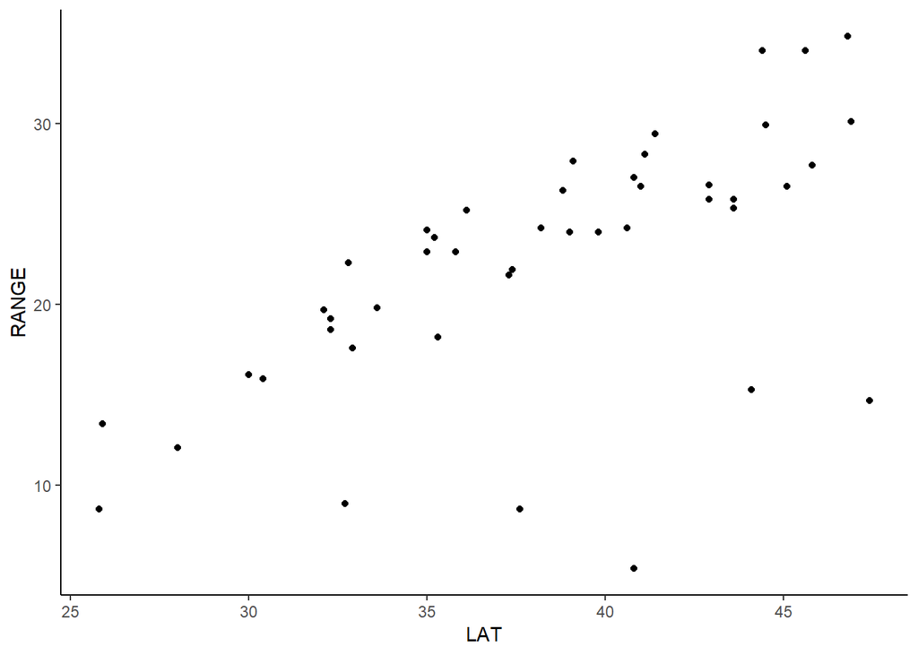

```r
ggplot(data = fw07p06,aes(x = LAT,y = RANGE))+
  geom_point()+
  theme_classic()
```

There seems to be a positive correlation between LAT (explanatory) and RANGE (dependent) variables.The relationship looks weak with some scatters. We can also observe a few potential outliers.

### 2. Use lm to fit the linear model: y = b0 + b1x + e. Explain briefly your findings,which should include the parameter estimates, the interpretation of the parameters and appropriate hypothesis test.

```r
## Fitting the model
model1 <- lm(RANGE ~ LAT, data=fw07p06)
summary(model1)
```

```
##
## Call:
## lm(formula = RANGE ~ LAT, data = fw07p06)
##
## Residuals:
##      Min       1Q   Median       3Q      Max
## -18.7823  -0.4865   0.8395   3.0765   7.1123
##
## Coefficients:
##             Estimate Std. Error t value Pr(>|t|)
## (Intercept)  -6.4793     5.5481  -1.168    0.249
## LAT           0.7515     0.1438   5.228 4.79e-06 ***
## ---
## Signif. codes:  0 '***' 0.001 '**' 0.01 '*' 0.05 '.' 0.1 ' ' 1
##
## Residual standard error: 5.498 on 43 degrees of freedom
## Multiple R-squared:  0.3886, Adjusted R-squared:  0.3744
## F-statistic: 27.33 on 1 and 43 DF,  p-value: 4.786e-06
```

Based on the R output above the regression coefficients are intercept(b0) = -6.47 and slope(b1) = 0.7515,which implies for 1 unit increase in LAT there will be 0.7515 increase for RANGE, and when LAT is zero RANGE will have a value of -6.47.

Hypotheses test: (We are assuming a significance level of 0.05)  
Null: b1 = 0  
Alternate: b1 != 0  
In other words we assume slope b1 in the below formula is zero.  
RANGE(predicted) = b0 + b1*LAT  
Which essentially means LAT deos not help to predict RANGE in our model.  
As we get a very small P-value(4.79e-06) < 0.05 from our test statistics, we will reject our null hypothese.  
Hence we can probably say LAT is a good predictor of RANGE and our model might be a good fit. How good? - that is yet to be investigated.

### 3. Write the estimated regression function.

```r
model1$coefficients
```

```
## (Intercept)         LAT
##  -6.4793304   0.7515107
```

Hence our model becomes:  
RANGE(predicted) = -6.47 + 0.7515*LAT.  
The regreession model plotted with ggplot2.

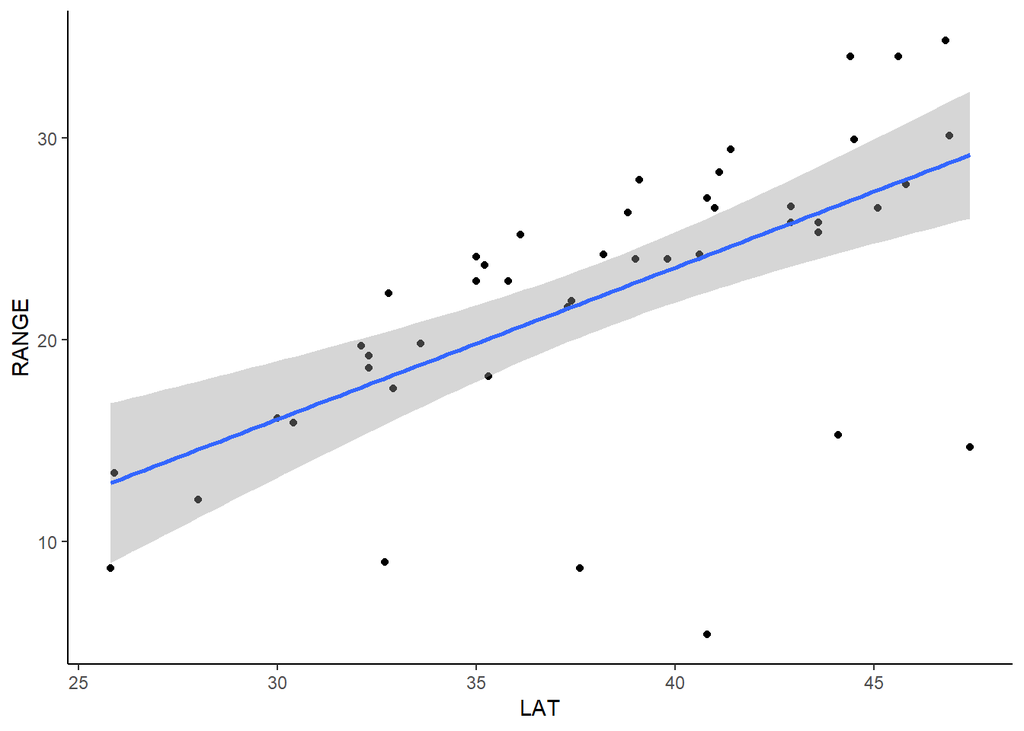

```r
ggplot(data = fw07p06,aes(x = LAT,y = RANGE))+
  geom_point()+
  geom_smooth(method=lm)+
  theme_classic()
```

### 4. Find the confidence interval for the intercept and the slope coefficients.

```r
confint(model1) #with default 5% significance level.
```

```
##                   2.5 %   97.5 %
## (Intercept) -17.6681689 4.709508
## LAT           0.4616029 1.041418
```

### 5. What proportion of the variability in the dependent variable RANGE is accounted for by LAT through the regression line ?

```r
summary(model1)$r.squared
```

```
## [1] 0.3885912
```

The explanatory variable LAT explains approximately 38.85% of the variability for the dependent RANGE variable, through the regression line.